# BST 222 Homework 7

November 12, 2018

## Exponential Distribution

- The **exponential distribution** is the probability distribution that describes the time between events in a Poisson point process.
- Exponential variables can be used to model situations where certain events occur with a constant probability per unit length, such as the distance between mutations on a DNA strand
- The probability density function (PDF) of an exponential distribution is given by \[f(x; \lambda) = \begin{cases}\lambda e^{-\lambda x} & x \geq 0 \\ 0 & x < 0 \end{cases}\] where \(\lambda > 0\) is the parameter of the distribution, often called the *rate parameter*

## Exponential PDF

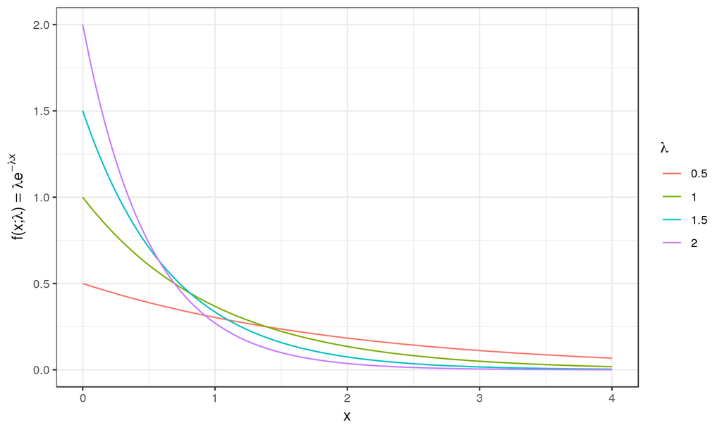

## Properties of \(X \sim Exp(\lambda)\)

- The **expected value** of \(X\) is given by \[E[X] = \frac{1}{\lambda}\]
- The **variance** of \(X\) is given by \[Var[X] = \frac{1}{\lambda^2}\]
- The **median** of \(X\) is given by \[m[X] = \frac{\ln (2)}{\lambda}\]

## Point Estimates of \(\lambda\)

Point estimation involves the use of sample data to calculate a single value which is to serve as a "best estimate" of an unknown population parameter. In the case of the exponential distribution, we are estimating the rate parameter, \(\lambda\). We will use the following three point estimators:

- Maximum Likelihood Estimator (MLE)
- 2nd Method of Moments Estimator
- Median as a function of \(\lambda\)

We will compare these estimators based on the following criteria:

- Bias
- Mean Squared Error (MSE)
- Consistiency

## MLE

The MLE for the exponential distribution can be derived as follows: \[L(\lambda ; x_1, ..., x_n) = \prod_{i=1}^{n} \lambda e^{-\lambda x_i} = \lambda^n e^{-\lambda \sum_{i=1}^{n} x_i}\] \[\ell(\lambda ; x_1, ..., x_n) = \log (\lambda^n) + \log (e^{-\lambda \sum_{i=1}^{n} x_i}) = n \log(\lambda) - \lambda \sum_{i=1}^{n} x_i\] \[U(\lambda) = \ell '(\lambda ; x_1, ..., x_n) = \frac{n}{\lambda} - \sum_{i=1}^{n} x_i\] \[\hat{\lambda} = \frac{n}{\sum_{i=1}^{n} x_i} = \frac{1}{\bar{x}}\]

## MLE Bias and Mean Squared Error

The MLE for the exponential distribution can be shown to be asymptotically unbiased given that: \[Bias[\hat{\lambda}] = E[\hat{\lambda}] - \lambda = nE[\frac{1}{\sum_{i=1}^n x_i}] - \lambda = \frac{n \lambda}{n-1} - \lambda = \frac{\lambda}{n-1}\] which approaches 0 as \(n \rightarrow \infty\). The variance of the MLE is \[Var(\hat{\lambda}) = \frac{1}{n * I_{exp}(\lambda)} = \frac{1}{n * -E[-\frac{1}{\lambda^2}]} = \frac{\lambda^2}{n}\] which means the mean squared error of the MLE is \[MSE[\hat{\lambda}] = \frac{\lambda^2}{n} + (\frac{\lambda}{n-1})^2 \]

## MLE Distributions and Consistiency

Given that the MLE estimator is asymptotically unbiased and \(\lim\limits_{n \to \infty} Var({\hat{\lambda_n}}) = 0\), then \(\hat{\lambda}_{MLE}\) is consistient.

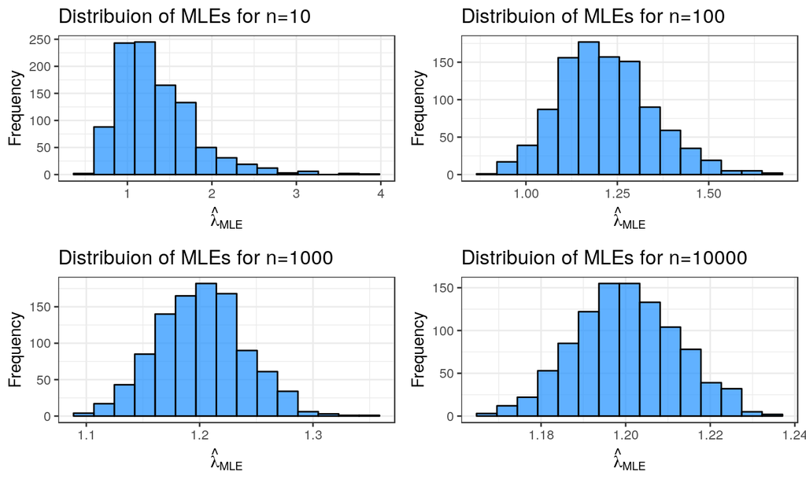

## MSE

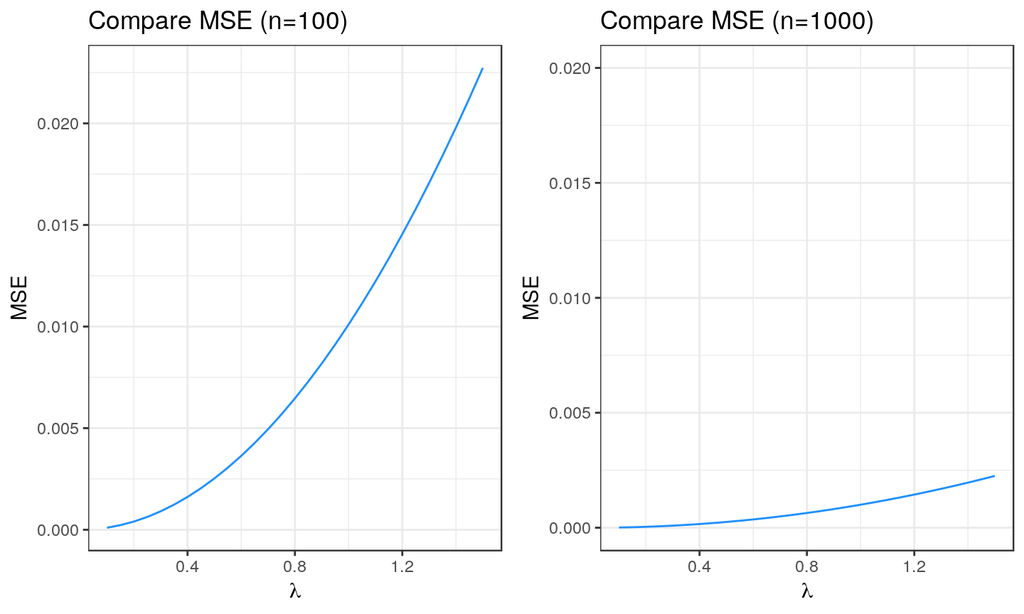